# GeoFunPhy

## Overview

GeoFunPhy is a tool used to classify the eco-evolutionary rarity of species varying in geographic, phylogenetic, and functional trait rarity. The ecological status proposed in GeoFunPhy can be used to infer larger organismal strategy.

- get_phy_angio() sources a choice of phylogeny from Smith & Brown 2018
- build_trait_data_LEDA() constructs a dataframe of chosen functional traits from the LEDA trait database
- calc_range_size() calculates the range size of species
- avg_evol_dist() calculates the evolutionary distinctiveness of species across distinct times and multiple phylogenetic extents
- fun_dist() calculates functional distinctiveness (FD) for species based on trait data
- scale_by_median() scales desired data within a dataframe using median z scores
- elbow_plot() displays an elbowplot for different K means for a variable
- compute_wcss() computes the Within-Cluster Sum of Squares (WCSS) for a given variable and a range of cluster values (k) using k-means clustering
- define_custom_k_ranges() performs k-means clustering on a variable and define custom ranges based on cluster centers
- check_EER_status_k() classifies the eco-evolutionary rarity (EER) of chosen species within a dataframe
- get_range_convex_hulls() creates convex hulls for a species using cleaned GBIF occurence data
- clip_polygons_to_land() clips range convex hulls to continent boundaries
- range_sizes() calculates the range size of clipped convex hulls
- get_continent_sf() reads and formats a GeoJSON document with continent data
- check_continents() checks which continents species convex hulls occur in
- check_biomes() checks which biomes species convex hulls occur in
- plot_convex_hulls() plots species’ occurence polygons onto a world map -plot_clipped_hulls() plots species’ clipped occurence polygons (clipped to continent bounds) onto a world map
- range_poly_map() creates and plots species’ occurence polygons onto a world map
- plot_EER_status() visualizes eco-evolutionary rarity categories in 3D space

## Installation

You can install the development version of GeoFunPhy like so:

```r
devtools::install_github("anytko/GeoFunPhy")
```

## Example

This is a basic example which demonstrates GeoFunPhy useage and shows how you can determine the eco-evolutionary status of common tree genera using SLA, seed_mass, and canopy_height. Note that certain functions, such as check_continents(), check_biomes(), and those called by calc_range_size() are not included. Please see the GeoFunPhy vignette for more information on extra functionality.

```r
library(GeoFunPhy)
```

## Create Trait Dataframe

```r
trait_df <- build_trait_data_LEDA(columns_to_select = c("SLA", "seed_mass", "canopy_height"), genera = c("Acer_", "Pinus_", "Fraxinus_", "Quercus_", "Tsuga_", "Ulmus", "Populus", "Betula_"))

trait_df <- rownames_to_column(trait_df, var = "species_name")
```

## Input Phylogeny

Users can input their own phylogeny or use one of the four phylogeneies listed in Smith & Brown 2018 including:

- ALLMB: GenBank and Open Tree of Life taxa with a backbone provided by Magallón et al. 2015
- ALLOTB: GenBank and Open Tree of Life taxa with a backbone provided by Open Tree of Life version 9.1
- GBMB: GenBank taxa with a backbone provided by Magallón et al. 2015
- GBOTB: GenBank taxa with a backbone provided by Open Tree of Life version 9.1”

```r
GBMB_phylogeny <- get_phy_angio("GBMB")
```

## Calculate Range Sizes

```r
range_sizes_df <- calc_range_size(data_frame = trait_df, num_cores = 7, gbif_limit = 2500)
```

## Plot Range Polygons

```r
acer_campestre_range <- data.frame(species_name = c("Acer campestre"))

range_poly_map(data_frame = acer_campestre_range)
# OR

continent_bounds <- get_continent_sf()
range_poly_map(data_frame = acer_campestre_range, clip = TRUE, continent_sf = continent_bounds)
```

## Calculate Average Evolutionary Distinctiveness

```r
trait_range_evol_df <- avg_evol_dist(phy = GBMB_phylogeny, data_frame = trait_df, num_cores = 6, time_slices = c(5, 10, 20, 35))
```

## Calculate Functional Distinctiveness

In order to calculate functional distinctiveness, we need to remove any species with NA values for any trait.

```r
merged_df <- merge(merge(trait_df, range_sizes_df, by = "species_name", all = TRUE), trait_range_evol_df, by = "species_name", all = TRUE)

merged_df <- na.omit(merged_df)
```

```r
fun_trait_range_evol_df <- fun_dist(data_frame = merged_df, trait_columns = c("SLA", "seed_mass", "canopy_height"))
```

## Transform Dataframe Around the Median

```r
scaled_df <- scale_by_median(data_frame = fun_trait_range_evol_df, columns_chosen = c("range_size", "mean_evol_dist"))
```

## Create Elbow Plots to Detmine Optimal K Means

### The optimal K means value can be determined by finding the “elbow” or bend in the plot. For example, in the three plots below a K = 3 represents the plot’s elbow.

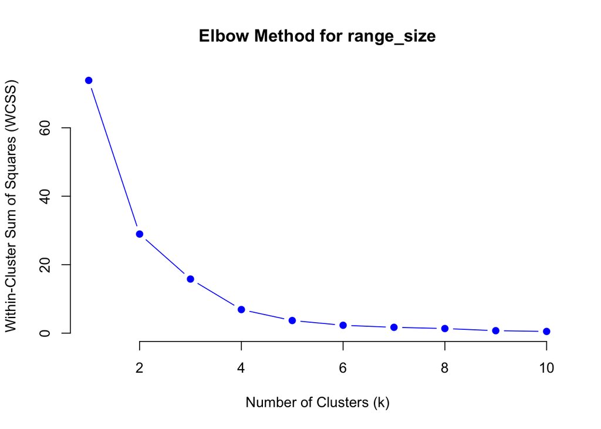

```r
range_elbow_plot <- elbow_plot(data = scaled_df, variable = "range_size")
```

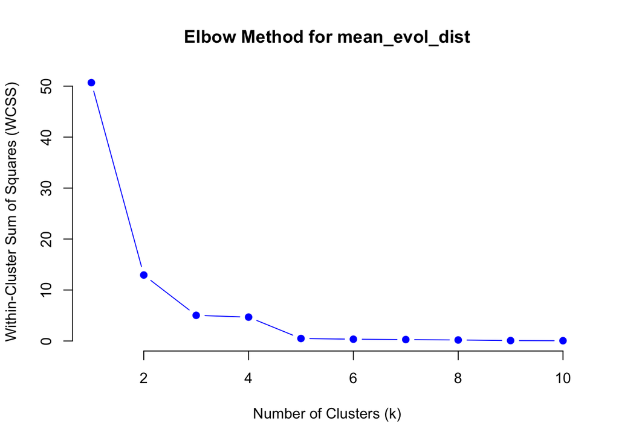

```r
evol_dist_elbow_plot <- elbow_plot(data = scaled_df, variable = "mean_evol_dist")
```

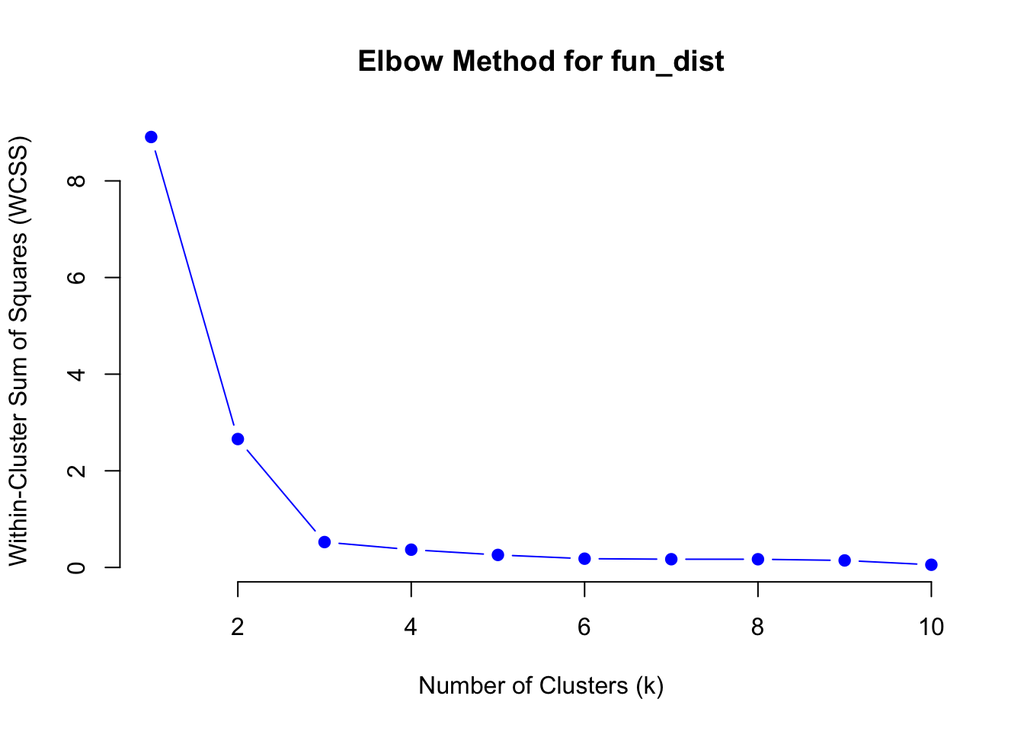

```r
fun_dist_elbow_plot <- elbow_plot(data = scaled_df, variable = "fun_dist")
```

## Determine Eco-Evolutionary Rarity Status

### Hint: Use the elbow plots above to determine optimal K means values

```r
eco_stat_df <- check_EER_status_k(data_frame = scaled_df, range_size_col = "range_size", mean_evol_dist_col = "mean_evol_dist", fun_dist_col = "fun_dist", range_size_k = 3, mean_evol_dist_k = 3, fun_dist_k = 3)
```

## Visualizing Eco-evolutionary Rarity Status

We can map the EER of species from this dataframe onto interactive 3D space. This object can be manipulated and positioned by the user in order to best visualize the respective ecological statuses.

```r
figure <- plot_EER_status(data_frame = eco_stat_df, fun_dist = "fun_dist", evol_dist = "mean_evol_dist", range_size = "range_size")
```